# Tidyverse

Aprende R

Xopre Rodríguez Gallego

15 de julio de 2025

# Introducción

En todos los casos será necesario lanzar la siguiente orden antes de nada:

```r
library(tidyverse)
```

# El operador tubería (`%>%`)

El operador tubería (`%>%`) es un operador binario que permite encadenar funciones, de forma que el resultado de la función anterior se convierte en el primer argumento de la siguiente función.

Podemos ver un ejemplo como sigue:

```r
# Creamos un vector
vec <- 1:5

# La versión original sería
sqrt(sum(vec))
```

```
## [1] 3.872983
```

```r
# Si queremos emplear el operador tubería
vec %>%
  sum() %>%
  sqrt()
```

```
## [1] 3.872983
```

En general, todas las funciones del entorno `tidyverse` están diseñadas para trabajar con el operador tubería.

## Ejemplo más elaborado

Creamos un data frame de ejemplo

```r
df <- data.frame(
  id = 1:5,
  valor = c(10, 20, 30, 40, 50),
  categoria = c("A", "B", "A", "B", "A")
)
```

Realizamos una serie de operaciones sin el operador tubería, accediendo a diferentes elementos

```r
df_filtrado <- df[df$categoria == "A", ]
df_sumado <- aggregate(valor ~ categoria, data = df_filtrado, FUN = sum)
df_ordenado <- df_sumado[order(df_sumado$valor, decreasing = TRUE), ]
```

Y ahora con el operador tubería

```r
df_ordenado_tuberia <- df %>%
  filter(categoria == "A") %>%
  group_by(categoria) %>%
  summarise(valor = sum(valor)) %>%
  arrange(desc(valor))
```

# `readr`

```r
library(readr)
```

> **Resumen**: Con este paquete es posible leer archivos de texto plano, como CSV, TSV, o archivos de ancho fijo, de forma rápida y eficiente, guardándolos como `tibble`.

Vamos a continuación a leer un archivo `especies.csv` usando `tidyverse`:

```r
# Leemos el archivo
datos <- read_csv("especies.csv")
# Y mostramos los datos
datos
```

```
## # A tibble: 16 × 9
##    Perteneciente.a Grupo.cientifico Grupo.comun Especie.científico Especie.comun
##    <chr>           <chr>            <chr>       <chr>              <chr>
##  1 Vertebrados     Reptilia         Reptiles    Testudo graeca     Tortuga Mora
##  2 Vertebrados     Anfibia          Anfibios    Alytes cisternasii Sapo partero…
##  3 Fauna           Invertebrata     Invertebra… Polyommatus golgus Niña de Sier…
##  4 Flora           Psilotaceae      Psilotáceas Psilotum nudum     <NA>
##  5 Vertebrados     Aves             Aves        Uria aalge         Arao común
##  6 Vertebrados     Peces            Peces       Acipenser sturio   Sollo
##  7 Flora           Isoetaceae       Isoetáceas  Isoetes setaceum   <NA>
##  8 Vertebrados     Aves             Aves        Upupa epops        Abubilla
##  9 Flora           Psilotaceae      Psilotáceas Psilotum nudum va… <NA>
## 10 Fauna           Invertebrata     Invertebra… Pinna nobilis      Nácar
## 11 Vertebrados     Peces            Peces       Anaecypris hispan… Jarabugo
## 12 Vertebrados     Peces            Peces       Cottus gobio       Cavilat
## 13 Flora           Isoetaceae       Isoetáceas  Isoetes durieui    <NA>
## 14 Vertebrados     Reptilia         Reptiles    Tarentola maurita… Salamanquesa…
## 15 Fauna           Invertebrata     Invertebra… Patella ferruginea Lapa ferrugí…
## 16 Vertebrados     Peces            Peces       Iberocypris palac… Bogardilla
## # ℹ 4 more variables: Endemicidad <chr>, PEZ.NO.PEZ <chr>, HACER.ESTUDIO <chr>,
## #   Nombre.comun <chr>
```

Al igual que `read_csv()`, en `readr` nos podemos encontrar con muchas otras funciones `read_*()` para diferentes formatos.

> **Nota**: Puede ser útil emplear la función `here()` del paquete `here` para ubicar rápidamente tu archivo.

# `tidyr`

> **Resumen**: Con este paquete es posible ajustar los datos para que cumplan las condiciones de ordenado (*tidy*), es decir, que cada variable tenga su propia columna, cada observación tenga su propia fila, y cada valor tenga su propia celda.
- [Hoja de referencia (*cheatsheet*)](https://raw.githubusercontent.com/rstudio/cheatsheets/main/tidyr.pdf)

# `dplyr`

> **Resumen**: Con este paquete es posible realizar operaciones de filtrado, selección, ordenación, agrupación, y resumen de datos, de forma rápida y eficiente.
- [Hoja de referencia (*cheatsheet*)](https://nyu-cdsc.github.io/learningr/assets/data-transformation.pdf)

Veamos a continuación algunos ejemplos, recurriendo al conjunto de datos `iris`:

```r
Data = iris
```

## Filtrado

```r
Data %>%
  filter(Species == "setosa") %>%
  head()
```

```
##   Sepal.Length Sepal.Width Petal.Length Petal.Width Species
## 1          5.1         3.5          1.4         0.2  setosa
## 2          4.9         3.0          1.4         0.2  setosa
## 3          4.7         3.2          1.3         0.2  setosa
## 4          4.6         3.1          1.5         0.2  setosa
## 5          5.0         3.6          1.4         0.2  setosa
## 6          5.4         3.9          1.7         0.4  setosa
```

```r
Data %>%
  filter(Species == "setosa" & Sepal.Length > 5) %>%
  head()
```

```
##   Sepal.Length Sepal.Width Petal.Length Petal.Width Species
## 1          5.1         3.5          1.4         0.2  setosa
## 2          5.4         3.9          1.7         0.4  setosa
## 3          5.4         3.7          1.5         0.2  setosa
## 4          5.8         4.0          1.2         0.2  setosa
## 5          5.7         4.4          1.5         0.4  setosa
## 6          5.4         3.9          1.3         0.4  setosa
```

## Selección

```r
Data %>%
  select(Species, Sepal.Length) %>%
  head()
```

```
##   Species Sepal.Length
## 1  setosa          5.1
## 2  setosa          4.9
## 3  setosa          4.7
## 4  setosa          4.6
## 5  setosa          5.0
## 6  setosa          5.4
```

También puede ser negativa:

```r
Data %>%
  select(-Species, -Sepal.Length) %>%
  head()
```

```
##   Sepal.Width Petal.Length Petal.Width
## 1         3.5          1.4         0.2
## 2         3.0          1.4         0.2
## 3         3.2          1.3         0.2
## 4         3.1          1.5         0.2
## 5         3.6          1.4         0.2
## 6         3.9          1.7         0.4
```

```r
# Análogo a
Data %>%
  select(-c(Species, Sepal.Length)) %>%
  head()
```

```
##   Sepal.Width Petal.Length Petal.Width
## 1         3.5          1.4         0.2
## 2         3.0          1.4         0.2
## 3         3.2          1.3         0.2
## 4         3.1          1.5         0.2
## 5         3.6          1.4         0.2
## 6         3.9          1.7         0.4
```

## Ordenación

```r
Data %>%
  arrange(Sepal.Length) %>%
  head()
```

```
##   Sepal.Length Sepal.Width Petal.Length Petal.Width Species
## 1          4.3         3.0          1.1         0.1  setosa
## 2          4.4         2.9          1.4         0.2  setosa
## 3          4.4         3.0          1.3         0.2  setosa
## 4          4.4         3.2          1.3         0.2  setosa
## 5          4.5         2.3          1.3         0.3  setosa
## 6          4.6         3.1          1.5         0.2  setosa
```

También podemos reordenar las columnas con `relocate()`, aunque esto no suele ser necesario:

```r
Data %>%
  relocate(Species, Sepal.Length) %>%
  head()
```

```
##   Species Sepal.Length Sepal.Width Petal.Length Petal.Width
## 1  setosa          5.1         3.5          1.4         0.2
## 2  setosa          4.9         3.0          1.4         0.2
## 3  setosa          4.7         3.2          1.3         0.2
## 4  setosa          4.6         3.1          1.5         0.2
## 5  setosa          5.0         3.6          1.4         0.2
## 6  setosa          5.4         3.9          1.7         0.4
```

## Agrupación

```r
Data %>%
  group_by(Species) %>%
  head()
```

```
## # A tibble: 6 × 5
## # Groups:   Species [1]
##   Sepal.Length Sepal.Width Petal.Length Petal.Width Species
##          <dbl>       <dbl>        <dbl>       <dbl> <fct>
## 1          5.1         3.5          1.4         0.2 setosa
## 2          4.9         3            1.4         0.2 setosa
## 3          4.7         3.2          1.3         0.2 setosa
## 4          4.6         3.1          1.5         0.2 setosa
## 5          5           3.6          1.4         0.2 setosa
## 6          5.4         3.9          1.7         0.4 setosa
```

Desde ahora, todas las operaciones se realizarán sobre cada grupo, veamos un ejemplo con `slice_max()`, primero sin agrupar y luego agrupando:

```r
Data %>%
  slice_max(Sepal.Length) %>%
  head()
```

```
##   Sepal.Length Sepal.Width Petal.Length Petal.Width   Species
## 1          7.9         3.8          6.4           2 virginica
```

```r
Data %>%
  group_by(Species) %>%
  slice_max(Sepal.Length) %>%
  head()
```

```
## # A tibble: 3 × 5
## # Groups:   Species [3]
##   Sepal.Length Sepal.Width Petal.Length Petal.Width Species
##          <dbl>       <dbl>        <dbl>       <dbl> <fct>
## 1          5.8         4            1.2         0.2 setosa
## 2          7           3.2          4.7         1.4 versicolor
## 3          7.9         3.8          6.4         2   virginica
```

### Resumen

Una operación especialmente interesante es la de resumen, que nos permite obtener valores agregados de las columnas:

```r
Data %>%
  summarise(mean(Sepal.Length))
```

```
##   mean(Sepal.Length)
## 1           5.843333
```

Así mola, pero al emplear `group_by()` podemos obtener resultados muuucho más interesantes.

```r
Data %>%
  group_by(Species) %>%
  summarise(mean(Sepal.Length))
```

```
## # A tibble: 3 × 2
##   Species    `mean(Sepal.Length)`
##   <fct>                     <dbl>
## 1 setosa                     5.01
## 2 versicolor                 5.94
## 3 virginica                  6.59
```

## Mutación/Valores derivados

Usamos `mutate()` para obtener valores derivados, como diferencias entre columnas:

```r
Data %>%
  mutate(Sepal.Width - Sepal.Length) %>%
  head()
```

```
##   Sepal.Length Sepal.Width Petal.Length Petal.Width Species
## 1          5.1         3.5          1.4         0.2  setosa
## 2          4.9         3.0          1.4         0.2  setosa
## 3          4.7         3.2          1.3         0.2  setosa
## 4          4.6         3.1          1.5         0.2  setosa
## 5          5.0         3.6          1.4         0.2  setosa
## 6          5.4         3.9          1.7         0.4  setosa
##   Sepal.Width - Sepal.Length
## 1                       -1.6
## 2                       -1.9
## 3                       -1.5
## 4                       -1.5
## 5                       -1.4
## 6                       -1.5
```

```r
Data %>%
  mutate(Diferencia = Sepal.Width - Sepal.Length) %>%
  head()
```

```
##   Sepal.Length Sepal.Width Petal.Length Petal.Width Species Diferencia
## 1          5.1         3.5          1.4         0.2  setosa       -1.6
## 2          4.9         3.0          1.4         0.2  setosa       -1.9
## 3          4.7         3.2          1.3         0.2  setosa       -1.5
## 4          4.6         3.1          1.5         0.2  setosa       -1.5
## 5          5.0         3.6          1.4         0.2  setosa       -1.4
## 6          5.4         3.9          1.7         0.4  setosa       -1.5
```

# Ejercicios

Recurriendo a los paquetes mencionados, realiza las siguientes operaciones:

- Lee tu conjunto de datos como un `tibble`, recurriendo al paquete `readr`, y posiblemente a alguna de las funciones `read_*()`.
- Visualiza los datos con las siguientes funciones:
  - `head()`
  - `glimpse()`
  - `summary()`
- Comprueba si tu conjunto de datos verifica las condiciones sobre datos ordenados (*tidy*), o si es necesario recurrir al paquete `tidyr` para ajustarlo. Recuerda que las condiciones para que una tabla se considere ordenada son las siguientes:
  - Cada variable debe tener su propia columna (*each variable must have its own column*).
  - Cada observación debe tener su propia fila (*each observation must have its own row*).
  - Cada valor debe tener su propia celda (*each value must have its own cell*).
- Recurriendo a `dplyr`, realiza las siguientes operaciones:
  - Filtra las observaciones que cumplan una condición.
  - Selecciona las columnas que te interesen.
  - Ordena las observaciones según una o varias columnas.
  - Agrupa las observaciones según una o varias columnas.
    - Emplea la función `summarize()` sobre el conjunto de datos agrupados.
  - Obtén valores derivados con `mutate()`, tales como:
    - Diferencias entre columnas.

## Ejercicios avanzados

Recurriendo a cualquiera de los siguientes recursos obtén una o más representaciones de una o más variables de tu conjunto de datos, recurriendo al paquete `ggplot2`:

- Una IA.
- [La hoja de referencia de ggplot2](https://raw.githubusercontent.com/rstudio/cheatsheets/main/data-visualization-2.1.pdf).
- [Estos ejemplos de representaciones](https://r-graph-gallery.com/ggplot2-package.html)

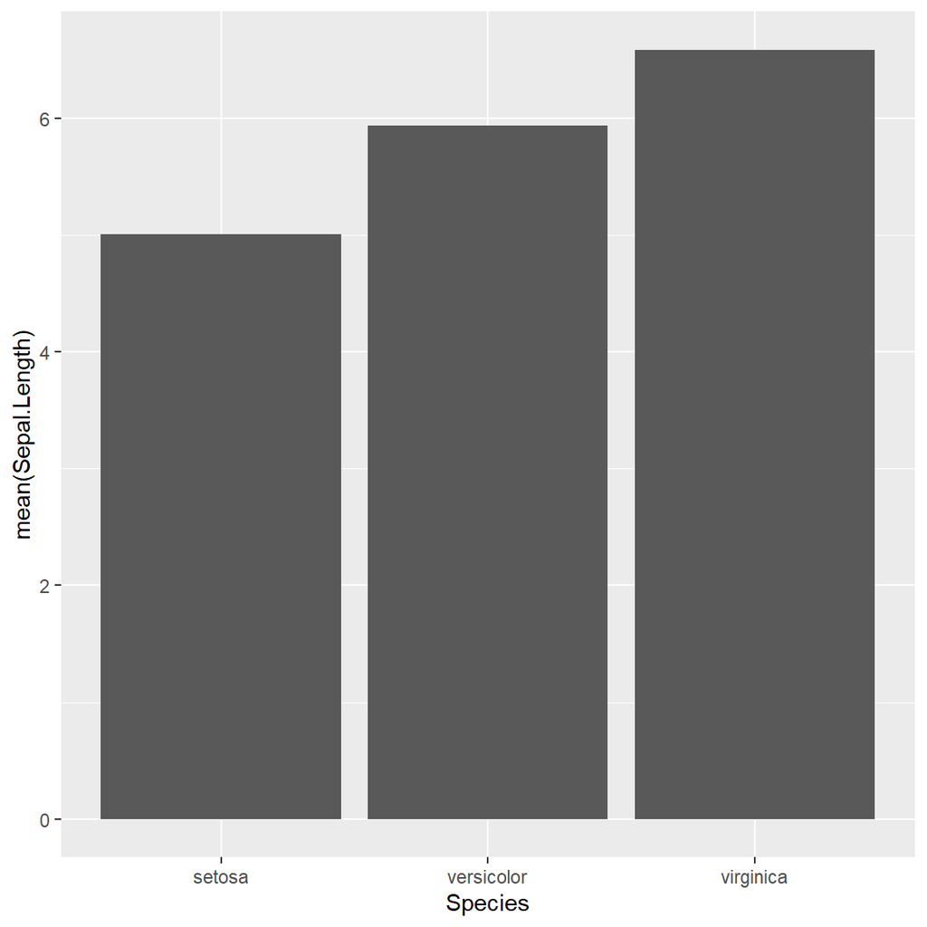

```r
Data %>%
  # Quiero que la especie sea un factor
  mutate(Species = as.factor(Species)) %>%
  # filter(Species == "setosa") %>%
  group_by(Species) %>%
  summarise(mean(Sepal.Length)) %>%
  ggplot(aes(x = Species, y = `mean(Sepal.Length)`)) +
  geom_col()
```

# Paquetes relacionados

## `magrittr`

Al final no lo usaremos al estar dentro de `dplyr` el operador tubería (`%>%`).